# Caso Pŕactico Final Evaluable PEDRO LLULL

Tomaremos el dataset Salaries.csv

El conjunto de datos consiste en los salarios de nueve meses recogidos de 397 profesores universitarios en los EE.UU. durante 2008 y 2009. Además de los salarios, también se recogió el rango del profesor, el sexo, la disciplina, los años desde el doctorado y los años de servicio. Así, hay un total de 6 variables, que se describen a continuación.

```
  1. rank: Categórica - de profesor asistente, profesor asociado o catedrático
  2. discipline: Categórica - Tipo de departamento en el que trabaja el profesor, ya sea aplicado (B) o teórico (A)
  3. yrs.since.phd: Continuo - Número de años desde que el profesor obtuvo su doctorado
  4. yrs.service: Continuo - Número de años que el profesor ha prestado servicio al departamento y/o a la universidad
  5. sex: Categórico - Sexo del profesor, hombre o mujer
  6. salary: Continuo - Sueldo de nueve meses del profesor (USD)
```

El objetivo de esta práctica consiste en realizar un estudio íntegro del dataset para terminar implementando un modelo lineal regularizado que realice predicciones sobre el salario a percibir de un profesor. Asimismo, se pedirá aprovechar la explicabilidad de estos modelos y los estudios estadísticos realizados para arrojar intuiciones y dependencias en los datos.

Para ello, se pide al estudiante que realice los siguientes pasos:

1. Carga los datos. Realiza una inspección por variables de la distribución de salarios en función de cada atributo visualmente. Realiza las observaciones pertinentes. ¿Qué variables son mejores para separar los datos?

```r
profes <- read.csv("Salaries.csv")
head(profes)
```

|  | X | rank | discipline | yrs.since.phd | yrs.service | sex | salary |
| --- | --- | --- | --- | --- | --- | --- | --- |
| 1 | 1 | Prof | B | 19 | 18 | Male | 139750 |
| 2 | 2 | Prof | B | 20 | 16 | Male | 173200 |
| 3 | 3 | AsstProf | B | 4 | 3 | Male | 79750 |
| 4 | 4 | Prof | B | 45 | 39 | Male | 115000 |
| 5 | 5 | Prof | B | 40 | 41 | Male | 141500 |
| 6 | 6 | AssocProf | B | 6 | 6 | Male | 97000 |

```r
# Voy a eliminar la primera columna que se crea desde el CSV, ya que no aporta nada
profes <- subset(profes, select = -X)

head(profes)
```

|  | rank | discipline | yrs.since.phd | yrs.service | sex | salary |
| --- | --- | --- | --- | --- | --- | --- |
| 1 | Prof | B | 19 | 18 | Male | 139750 |
| 2 | Prof | B | 20 | 16 | Male | 173200 |
| 3 | AsstProf | B | 4 | 3 | Male | 79750 |
| 4 | Prof | B | 45 | 39 | Male | 115000 |
| 5 | Prof | B | 40 | 41 | Male | 141500 |
| 6 | AssocProf | B | 6 | 6 | Male | 97000 |

```r
tail(profes)
```

|  | rank | discipline | yrs.since.phd | yrs.service | sex | salary |
| --- | --- | --- | --- | --- | --- | --- |
| 392 | Prof | A | 30 | 19 | Male | 151292 |
| 393 | Prof | A | 33 | 30 | Male | 103106 |
| 394 | Prof | A | 31 | 19 | Male | 150564 |
| 395 | Prof | A | 42 | 25 | Male | 101738 |
| 396 | Prof | A | 25 | 15 | Male | 95329 |
| 397 | AsstProf | A | 8 | 4 | Male | 81035 |

```r
summary(profes)
```

```
     rank            discipline        yrs.since.phd    yrs.service        sex                salary
 Length:397         Length:397         Min.   : 1.00   Min.   : 0.00   Length:397         Min.   : 57800
 Class :character   Class :character   1st Qu.:12.00   1st Qu.: 7.00   Class :character   1st Qu.: 91000
 Mode  :character   Mode  :character   Median :21.00   Median :16.00   Mode  :character   Median :107300
                                       Mean   :22.31   Mean   :17.61                      Mean   :113706
                                       3rd Qu.:32.00   3rd Qu.:27.00                      3rd Qu.:134185
                                       Max.   :56.00   Max.   :60.00                      Max.   :231545
```

```r
# Verifico que no haya valores nulos
colSums(is.na(profes))
```

```
         rank    discipline yrs.since.phd   yrs.service           sex        salary
            0             0             0             0             0             0
```

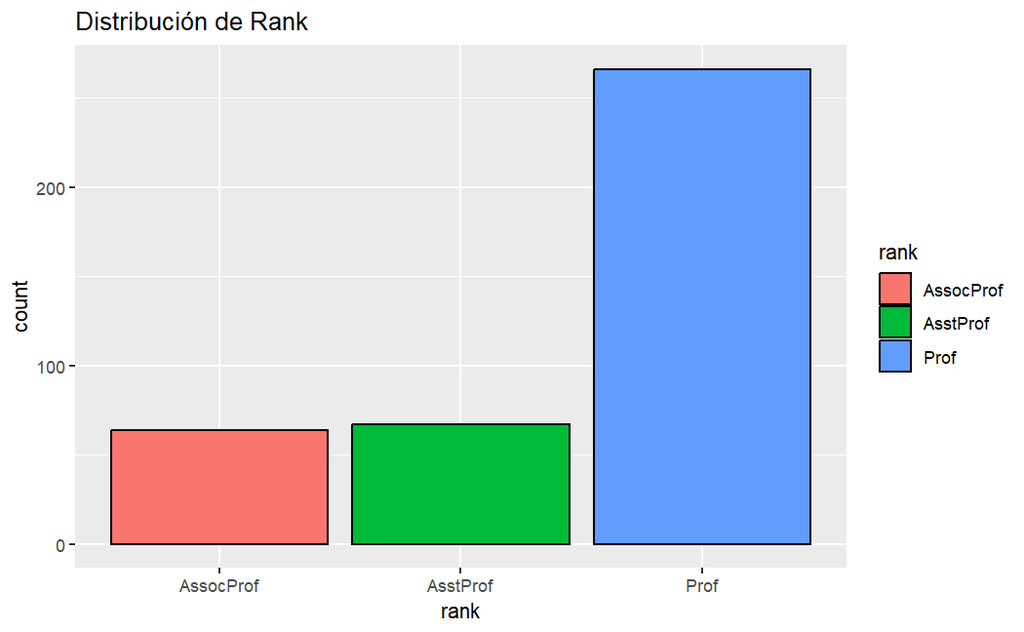

```r
# Vamos a ver los datos de forma descriptiva o visual, empezando por los básicos
library(ggplot2)

# Gráfica de distribución para 'rank'
ggplot(profes, aes(x = rank, fill = rank)) +
  geom_bar(color = "black") +
  labs(title = "Distribución de Rank")
```

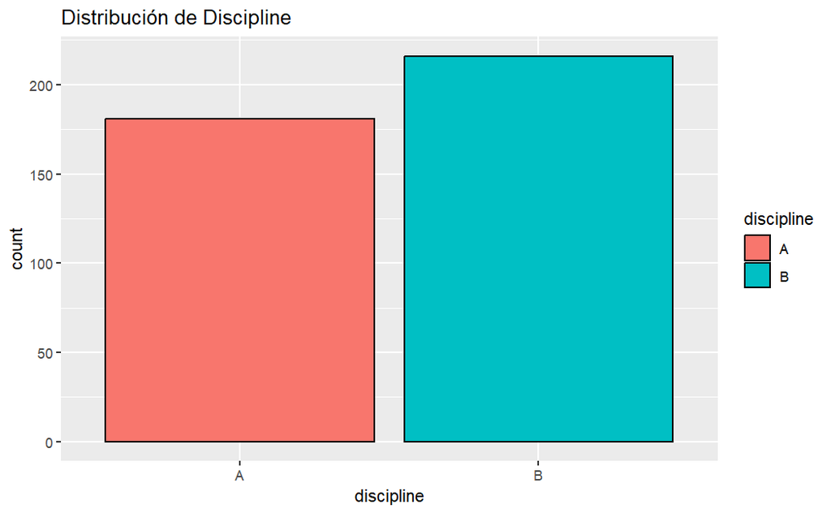

```r
# Gráfica de distribución para 'discipline'
ggplot(profes, aes(x = discipline, fill = discipline)) +
  geom_bar(color = "black") +
  labs(title = "Distribución de Discipline")
```

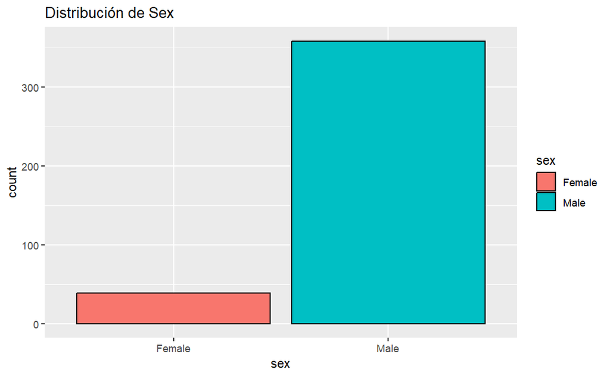

```r
# Gráfica de distribución para 'sex'
ggplot(profes, aes(x = sex, fill = sex)) +
  geom_bar(color = "black") +
  labs(title = "Distribución de Sex")
```

[output not shown]

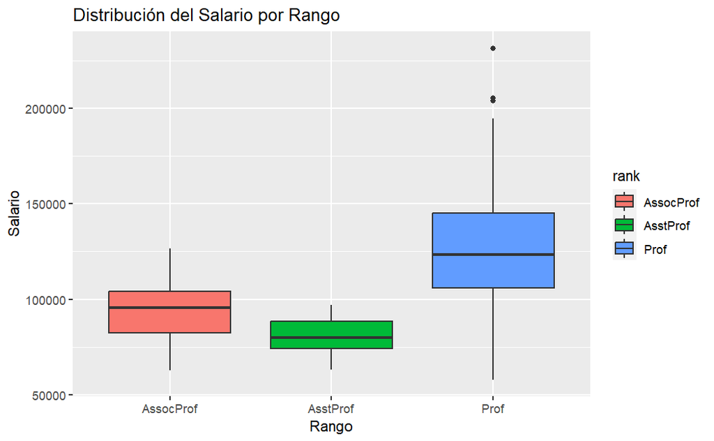

```r
# Ahora Boxplot para ver como se comportan las categóricas y scatterplots para las continuas
library(ggplot2)

ggplot(profes, aes(x = rank, y = salary, fill = rank)) +
  geom_boxplot() +
  labs(title = "Distribución del Salario por Rango", x = "Rango", y = "Salario")
```

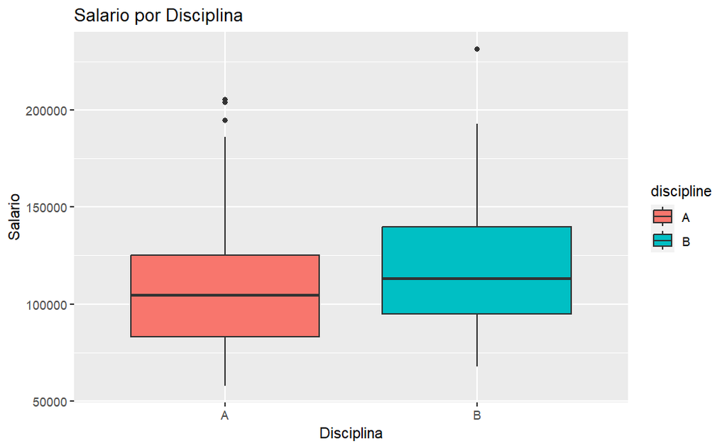

```r
ggplot(profes, aes(x = discipline, y = salary, fill = discipline)) +
  geom_boxplot() +
  labs(title = "Salario por Disciplina", x = "Disciplina", y = "Salario")
```

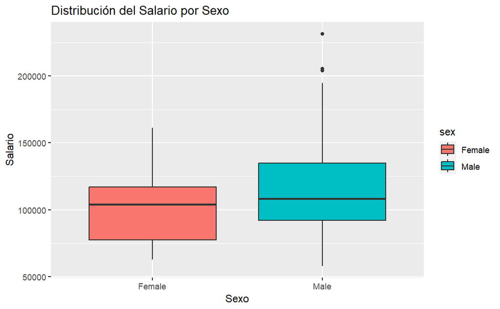

```r
ggplot(profes, aes(x = sex, y = salary, fill = sex)) +
  geom_boxplot() +
  labs(title = "Distribución del Salario por Sexo", x = "Sexo", y = "Salario")
```

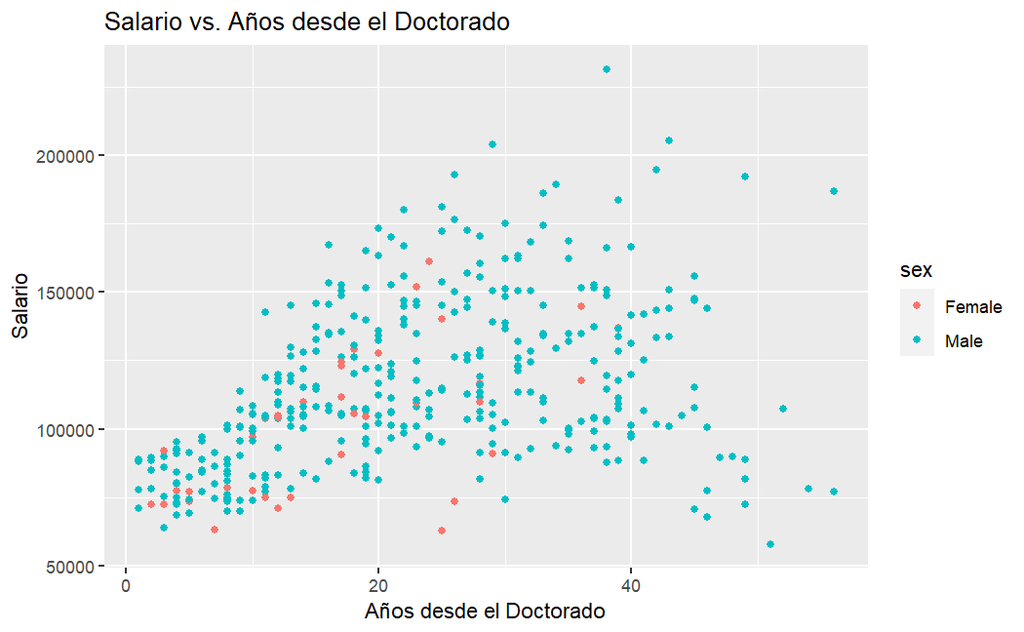

```r
# En los Scatter añadí el sexo para ver un poco la diferencia entre H y M
ggplot(profes, aes(x = yrs.since.phd, y = salary, color=sex)) +
  geom_point() +
  labs(title = "Salario vs. Años desde el Doctorado", x = "Años desde el Doctorado", y = "Salario")
```

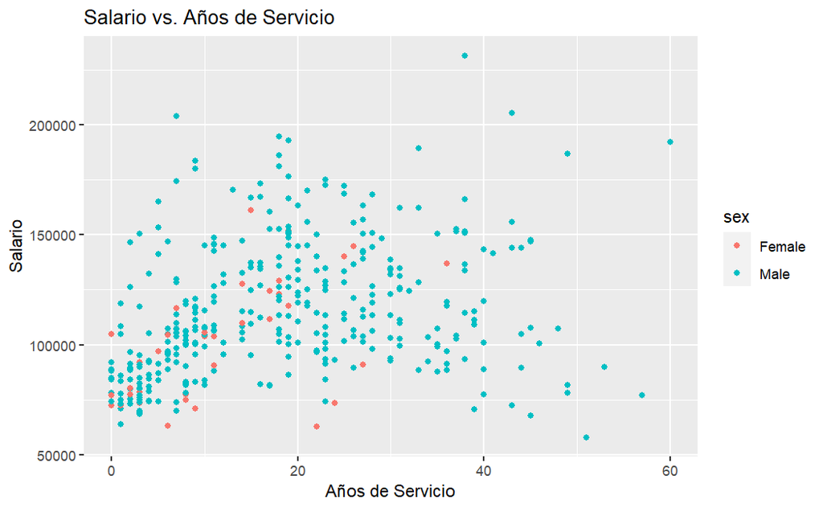

```r
ggplot(profes, aes(x = yrs.service, y = salary, color=sex)) +
  geom_point() +
  labs(title = "Salario vs. Años de Servicio", x = "Años de Servicio", y = "Salario")
```

1. Distribución de Salario por Rango

   Prof: Los profesores titulares (Prof) tienen un rango más amplio de salarios, con una mediana más alta comparada con los otros rangos. Hay algunos outliers en el extremo superior, indicando que algunos profesores titulares ganan significativamente más que sus colegas. AssocProf: Los profesores asociados tienen un rango de salarios más estrecho y una mediana más baja comparada con los profesores titulares. AsstProf: Los profesores asistentes tienen el rango de salarios más bajo y la mediana más baja. No hay outliers en este grupo.
2. Distribución de Salario por Disciplina

   A: La disciplina A muestra un rango de salarios ligeramente más estrecho que la disciplina B, y su mediana está un poco más baja. B: La disciplina B tiene un rango de salarios más amplio y su mediana es ligeramente más alta.
3. Distribución de Salario por Sexo

   No se observa una tendencia clara que indique que los salarios aumentan con el número de años desde el doctorado. Sin embargo, hay una concentración de salarios más bajos para aquellos con menos años desde el PhD. Los datos se DISPERSAN mucho así como aumentan los años.
5. Distribución de Salario vs. Años de Servicio

   Similar a los años desde el PhD, no hay una tendencia clara que relacione los años de servicio con los salarios. Hay una variabilidad considerable en los salarios, independientemente de los años de servicio. AL igual que el caso anterior, así como pasan los años Aumenta mucho la dispersión de os datos.

¿Qué Variables son Mejores para Separar los Datos?

```
Rango: Es una variable clave para separar los datos, ya que muestra diferencias significativas en los salarios entre los diferentes rangos de profesores.
Sexo: También es clave, muestra diferencias notables en los salarios entre hombres y mujeres, lo cual podría ser un punto importante.
Disciplina: Aunque las diferencias no son tan marcadas como en el rango o el sexo, todavía hay variaciones que podrían ser útiles.
Las variables numéricas, "años desde el PhD" y "años de servicio", no muestran una relación clara con el salario.
```

2. ¿Podemos emplear un test paramétrico para determinar si las medias de salarios entre hombres y mujeres son las mismas o difieren? Ten en cuenta que, en tanto que se pide usar un test paramétrico, se deberá determinar si las muestras cumplen con las hipótesis necesarias.

   Podemos utilizar un test t de Student para comparar las medias de los salarios entre hombres y mujeres, ya que es un test paramétrico que se utiliza comúnmente para comparar las medias de dos grupos independientes.

   Sin embargo, para aplicar correctamente un test t, necesitamos verificar algunos puntos: Normalidad: Las distribuciones de las muestras deben ser aproximadamente normales. Esto se puede verificar visualmente con un histograma o un gráfico Q-Q, o utilizando pruebas estadísticas como la prueba de Shapiro-Wilk.

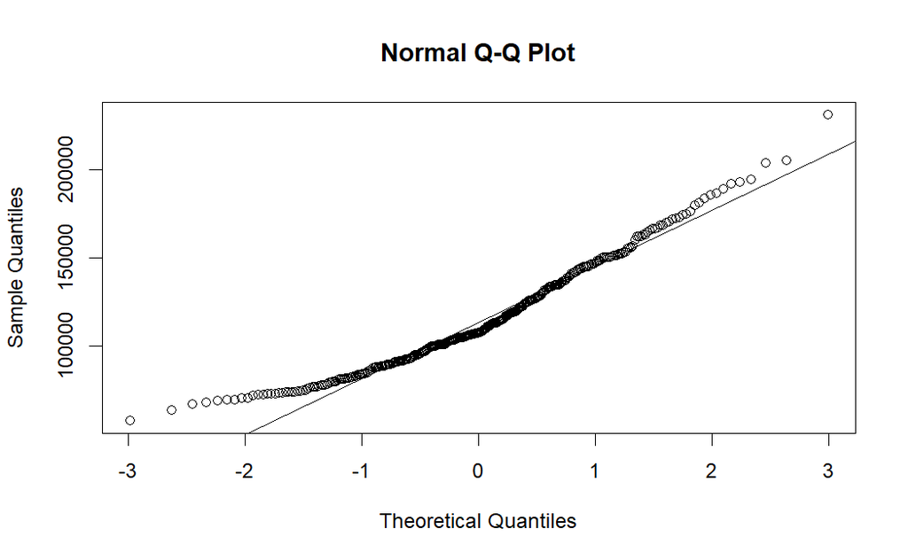

```r
# Vamos a ver de primeras como se comportan lod datos de los salarios para H y M en un Q-Q
salarios_hombres <- profes[profes$sex == 'Male', ]$salary
salarios_mujeres <- profes[profes$sex == 'Female', ]$salary

qqnorm(salarios_hombres)
qqline(salarios_hombres)
```

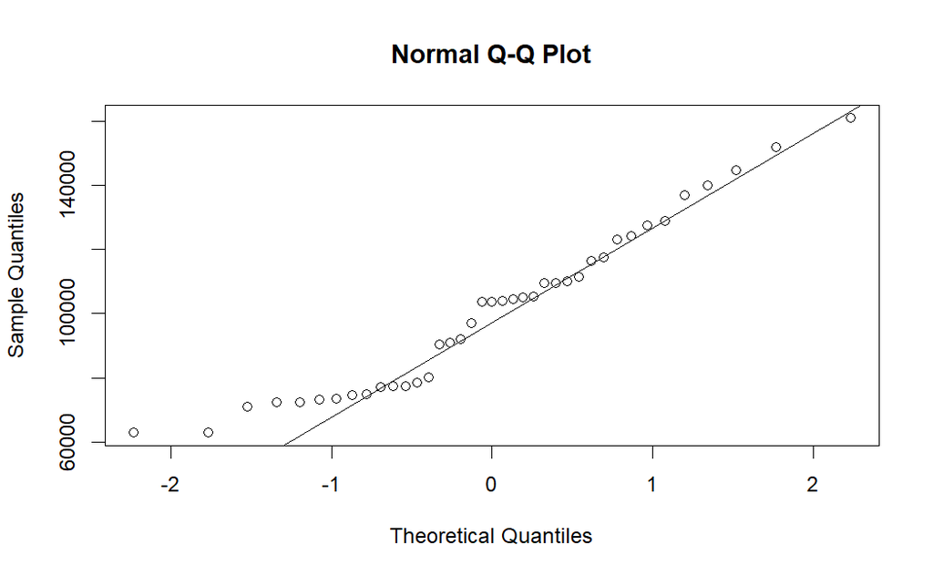

```r
qqnorm(salarios_mujeres)
qqline(salarios_mujeres)
```

Gráfico Q-Q para Salarios de Hombres

```
Los puntos siguen bastante bien la línea en la distribución, parece que la parte central de la distribución es bastante normal. Hay algunas desviaciones en los extremos, lo que indica que hay outliers.
```

Gráfico Q-Q para Salarios de Mujeres

```
Al igual que con los hombres, los puntos siguen bastante bien la línea en el centro de la distribución, aunque parece algo más irregular. También hay algunas desviaciones en los extremos.
```

```r
# Prueba de Shapiro-Wilk para evaluar la normalidad de las distribuciones de salarios en hombres y mujeres.
shapiro.test(profes$salary[profes$sex == "Male"])
```

```
    Shapiro-Wilk normality test

data:  profes$salary[profes$sex == "Male"]
W = 0.95877, p-value = 1.735e-08
```

```r
shapiro.test(profes$salary[profes$sex == "Female"])
```

```
    Shapiro-Wilk normality test

data:  profes$salary[profes$sex == "Female"]
W = 0.94665, p-value = 0.06339
```

```
Hombres: Dado que el valor p es menor que 0.05, rechazamos la hipótesis nula, sugiriendo que los salarios de los hombres no siguen una distribución normal.
Mujeres: El valor p es mayor que 0.05, lo que significa que no rechazamos la hipótesis nula, sugiriendo que los salarios de las mujeres podrían provenir de una distribución normal.

Aunque la muestra de mujeres no rechazó la hipótesis nula de normalidad, la muestra de hombres sí lo hizo. Esto podría deberse al tamaño de la muestra y a la presencia de outliers, como se observó en los gráficos Q-Q.
```

```r
# Este test asume que las muestras provienen de distribuciones normales con varianzas iguales. Hemos visto que la distribución de salarios para los hombres no es normal, por lo que los resultados de este test deben ser tomados con PRECAUCIÓN.
salarios_hombres <- profes$salary[profes$sex == "Male"]
salarios_mujeres <- profes$salary[profes$sex == "Female"]
resultado_t_test <- t.test(salarios_hombres, salarios_mujeres)
print(resultado_t_test)
```

```
    Welch Two Sample t-test

data:  salarios_hombres and salarios_mujeres
t = 3.1615, df = 50.122, p-value = 0.002664
alternative hypothesis: true difference in means is not equal to 0
95 percent confidence interval:
  5138.102 23037.916
sample estimates:
mean of x mean of y
 115090.4  101002.4
```

[output not shown]

```r
# La prueba de Mann-Whitney U es una prueba no paramétrica que se utiliza para determinar si hay diferencias significativas entre las distribuciones de dos grupos independientes.
resultado_mann_whitney <- wilcox.test(salary ~ sex, data = profes)
print(resultado_mann_whitney)
```

```
    Wilcoxon rank sum test with continuity correction

data:  salary by sex
W = 5182.5, p-value = 0.008237
alternative hypothesis: true location shift is not equal to 0
```

```
El valor p es menor que 0.05, lo que nos lleva a rechazar la hipótesis nula. Esto sugiere que hay una diferencia significativa entre las distribuciones de salarios de hombres y mujeres.

Al igual que la Prueba T de Student, la prueba de Mann-Whitney U indica que existen diferencias significativas entre los salarios de hombres y mujeres en este conjunto de datos.

Este resultado refuerza la conclusión de que existe una brecha salarial de género.

Dado que no teníamos el 100% de condiciones para el test t de Student, los resultados del test de Mann-Whitney U son probablemente más confiables, apoyando la conclusión de que las medianas de los salarios son diferentes entre los dos grupos.
```

3. Divide el dataset tomando las primeras 317 instancias como train y las últimas 80 como test. Entrena un modelo de regresión lineal con regularización Ridge y Lasso en train seleccionando el que mejor **MSE** tenga. Da las métricas en test. Valora el uso del One Hot Encoder, en caso de emplearlo arguméntalo.

   JuanMa nos ha comentado que la segregacion de variables categoricas a Dummyes penaliza horizontalmente los modelos, ya que añade más variables, sobretodo en modelos con muchas variables. Supongo que en un modelo como el que tenemos no hay problema, ya que no hay muchas variables.

   One Hot Encoding permite convertir las variables categóricas en variables dummy. Este método es útil porque los modelos de regresión lineal requieren entrada numérica y este tipo de codificación permite representar información categórica de una manera que los modelos pueden entender.

```r
# Uso dummyVars para aplicar One Hot Encoding
# Este método es difernte al que nos enseñaste, pero para mi deja las columnas más definidas (Lo vi en un ejemplo de StacKOverflow y ChatGPT también me lo recomendó)

#IGUALMENTE, EN EL ARCHIVO DE R "Puebas.Rmd" dejo el ejemplo con las pautas que nos enseñaste. Se puede ver que los resultados son casi iguales.

library(caret)

dummies_model <- dummyVars(" ~ .", data = profes)
profes_OH <- predict(dummies_model, newdata = profes)
head(profes_OH)
```

```
  rankAssocProf rankAsstProf rankProf disciplineA disciplineB yrs.since.phd yrs.service sexFemale sexMale salary
1             0            0        1           0           1            19          18         0       1 139750
2             0            0        1           0           1            20          16         0       1 173200
3             0            1        0           0           1             4           3         0       1  79750
4             0            0        1           0           1            45          39         0       1 115000
5             0            0        1           0           1            40          41         0       1 141500
6             1            0        0           0           1             6           6         0       1  97000
```

```r
# Índices para los conjuntos de entrenamiento y prueba
train_indices <- 1:317
test_indices <- 318:397

# Dividir los datos en conjuntos de entrenamiento y prueba
X_train <- profes_OH[train_indices, -ncol(profes_OH)]  # Todas las columnas excepto la última (salary)
y_train <- profes_OH[train_indices, ncol(profes_OH)]   # Solo la última columna (salary)

X_test <- profes_OH[test_indices, -ncol(profes_OH)]
y_test <- profes_OH[test_indices, ncol(profes_OH)]
```

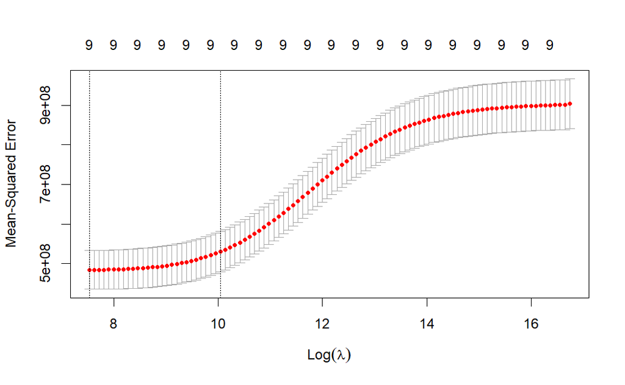

```r
library(glmnet)

set.seed(42)

# Ridge
cv.ridge <- cv.glmnet(X_train, y_train, family='gaussian', alpha=0, type.measure='mse')
plot(cv.ridge)
```

```r
cv.ridge$lambda.min
```

```
[1] 1865.816
```

```r
min(cv.ridge$cvm)
```

```
[1] 483698205
```

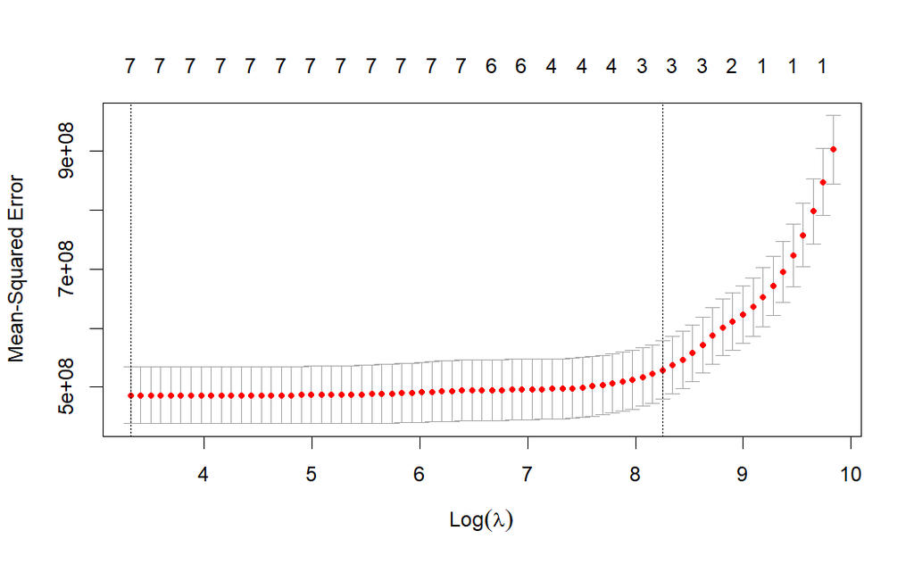

```r
# Lasso
cv.lasso <- cv.glmnet(X_train, y_train, family='gaussian', alpha=1, type.measure='mse')
plot(cv.lasso)
```

```r
cv.lasso$lambda.min
```

```
[1] 27.70678
```

```r
min(cv.lasso$cvm)
```

```
[1] 485996380
```

```
El modelo Ridge tiene un MSE ligeramente menor que el modelo Lasso en este caso, lo que indica que podría estar proporcionando un mejor ajuste a los datos.
```

```r
coef(cv.ridge, s=cv.ridge$lambda.min)
```

```
10 x 1 sparse Matrix of class "dgCMatrix"
                       s1
(Intercept)   100476.9329
rankAssocProf -10598.9852
rankAsstProf  -23086.9563
rankProf       21741.2330
disciplineA    -7407.5111
disciplineB     7377.0297
yrs.since.phd    377.7883
yrs.service     -420.6105
sexFemale      -1982.4151
sexMale         1992.1476
```

```r
coef(cv.lasso, s=cv.lasso$lambda.min)
```

```
10 x 1 sparse Matrix of class "dgCMatrix"
                         s1
(Intercept)    9.856191e+04
rankAssocProf  .
rankAsstProf  -1.321231e+04
rankProf       3.321618e+04
disciplineA   -1.545208e+04
disciplineB    3.775673e-09
yrs.since.phd  5.911746e+02
yrs.service   -6.620847e+02
sexFemale     -3.692386e+03
sexMale        .
```

```
El coeficiente para profesor asociado se ha reducido a cero, lo que indica que, después de la penalización Lasso, esta variable no está contribuyendo al modelo
```

```r
library(glmnet)
# Predecir y calcular el MSE real para Ridge
predictions_ridge <- predict(cv.ridge$glmnet.fit, s = cv.ridge$lambda.min, newx = X_test)
mse_ridge <- mean((y_test - predictions_ridge)^2)

# Predecir y calcular el MSE real para Lasso
predictions_lasso <- predict(cv.lasso$glmnet.fit, s = cv.lasso$lambda.min, newx = X_test)
mse_lasso <- mean((y_test - predictions_lasso)^2)

mse_ridge
```

```
[1] 629379301
```

```r
mse_lasso
```

```
[1] 642549192
```

```
    El Modelo Ridge tiene un MSE menor en el conjunto de prueba en comparación con el Modelo Lasso. Esto sugiere que el Modelo Ridge ha generalizado mejor a los datos.
A pesar de que el Modelo Lasso realizó una selección de características, eliminando algunos coeficientes al reducirlos a cero, esto no se tradujo en un mejor rendimiento en el conjunto de prueba en comparación con el Modelo Ridge.
```

```r
#predict.glmnet(cv.ridge$glmnet.fit, s = cv.ridge$lambda.min, newx=X_test)
#predict.glmnet(cv.lasso$glmnet.fit, s = cv.lasso$lambda.min, newx=X_test)
```

```
Aunque no se pide explicitamente, voy a probar con ELASTICNET para ver y comparar los resultados
```

```r
cv.elasticnet <- cv.glmnet(X_train, y_train, family='gaussian', alpha=0.5, type.measure='mse')

# Predicciones en el conjunto de entrenamiento
predictions_train <- predict(cv.elasticnet$glmnet.fit, s = cv.elasticnet$lambda.min, newx = X_train)
mse_train <- mean((y_train - predictions_train)^2)

# Predicciones en el conjunto de prueba
predictions_test <- predict(cv.elasticnet$glmnet.fit, s = cv.elasticnet$lambda.min, newx = X_test)
mse_test <- mean((y_test - predictions_test)^2)

mse_train
```

```
[1] 467304316
```

```r
mse_test
```

```
[1] 642456275
```

```r
coef(cv.elasticnet, s=cv.elasticnet$lambda.min)
```

```
10 x 1 sparse Matrix of class "dgCMatrix"
                       s1
(Intercept)    89458.9184
rankAssocProf      .
rankAsstProf  -13233.2593
rankProf       33184.8419
disciplineA    -7989.9455
disciplineB     7464.5373
yrs.since.phd    590.4237
yrs.service     -660.9904
sexFemale      -2046.7777
sexMale         1663.0394
```

```
Ajustando más del lado de RIDGE ya que nos ha dado mejor resultado en las pruebas individuales de RIDGE y LASSO
```

```r
# Ajustar el modelo Elastic Net
cv.elasticnet <- cv.glmnet(X_train, y_train, family='gaussian', alpha=0.2, type.measure='mse')

# Predicciones en el conjunto de entrenamiento
predictions_train <- predict(cv.elasticnet$glmnet.fit, s = cv.elasticnet$lambda.min, newx = X_train)
mse_train <- mean((y_train - predictions_train)^2)

# Predicciones en el conjunto de prueba
predictions_test <- predict(cv.elasticnet$glmnet.fit, s = cv.elasticnet$lambda.min, newx = X_test)
mse_test <- mean((y_test - predictions_test)^2)

mse_train
```

```
[1] 467471894
```

```r
mse_test
```

```
[1] 639871403
```

```r
coef(cv.elasticnet, s=cv.elasticnet$lambda.min)
```

```
10 x 1 sparse Matrix of class "dgCMatrix"
                       s1
(Intercept)    95771.3931
rankAssocProf  -6366.1570
rankAsstProf  -19599.3169
rankProf       26767.6339
disciplineA    -7735.5935
disciplineB     7574.1620
yrs.since.phd    541.1703
yrs.service     -611.4731
sexFemale      -1875.0910
sexMale         1797.4985
```

Resultados:

```
Modelo Elastic Net α=0.2:
    MSE en Train: 467,471,894
    MSE en Test: 639,871,403
```

Comparación con Modelos Anteriores:

```
Ridge:
    MSE en Test: 629,379,301
Lasso:
    MSE en Test: 642,549,192
Elastic Net con α=0.5:
    MSE en Test: 642,456,275
```

Podemos observar que:

```
El modelo Elastic Net con α=0.2 tiene un MSE en el conjunto de prueba que está entre los MSE de los modelos Ridge y Lasso, indicando un rendimiento intermedio.

Comparado con el modelo Elastic Net con α=0.5, el modelo con α=0.2α=0.2 tiene un MSE en el conjunto de prueba ligeramente menor, indicando un mejor rendimiento.
```

4. Estudia la normalidad de los residuos del modelo resultante, ¿detectas algún sesgo?

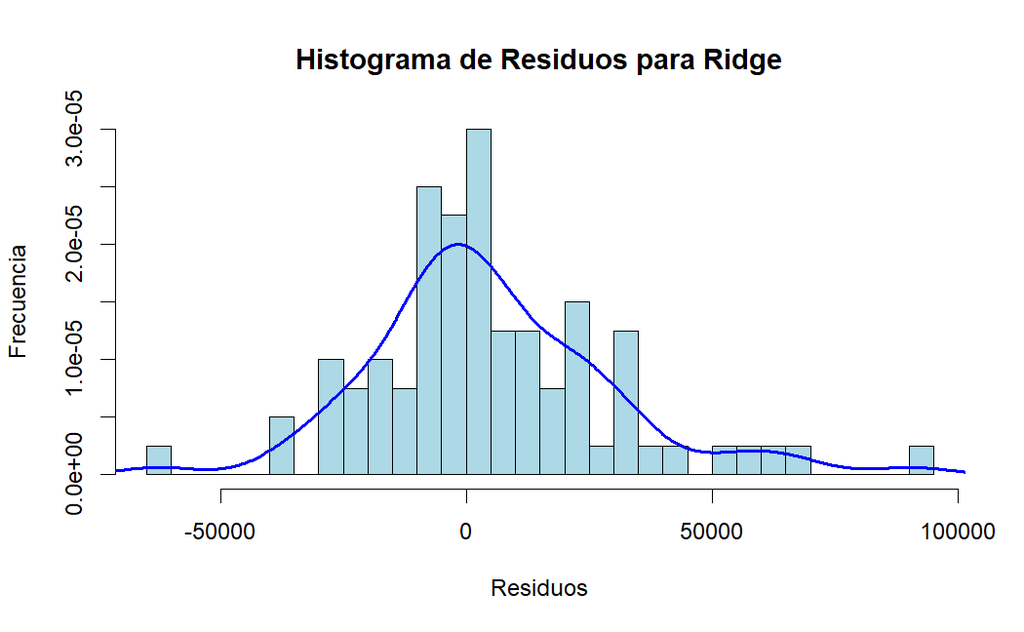

```r
# Calcular residuos para Ridge y Lasso
residuos_ridge <- y_test - predictions_ridge
residuos_lasso <- y_test - predictions_lasso

# Gráfico de histograma para residuos de Ridge
hist(residuos_ridge, main="Histograma de Residuos para Ridge", xlab="Residuos", ylab="Frecuencia", col='lightblue', border="black", breaks=50, probability=TRUE)
lines(density(residuos_ridge), col="blue", lwd=2)
```

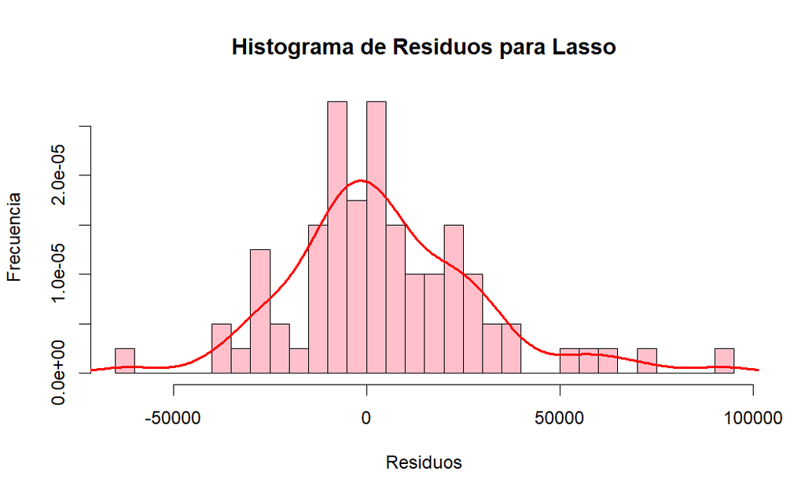

```r
# Gráfico de histograma para residuos de Lasso
hist(residuos_lasso, main="Histograma de Residuos para Lasso", xlab="Residuos", ylab="Frecuencia", col= 'pink', border="black", breaks=50, probability=TRUE)
lines(density(residuos_lasso), col="red", lwd=2)
```

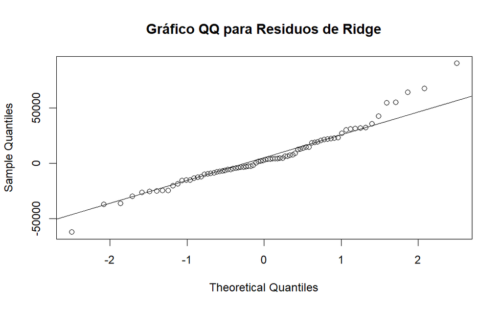

```r
# Gráfico QQ para residuos de Ridge
qqnorm(residuos_ridge, main="Gráfico QQ para Residuos de Ridge")
qqline(residuos_ridge)
```

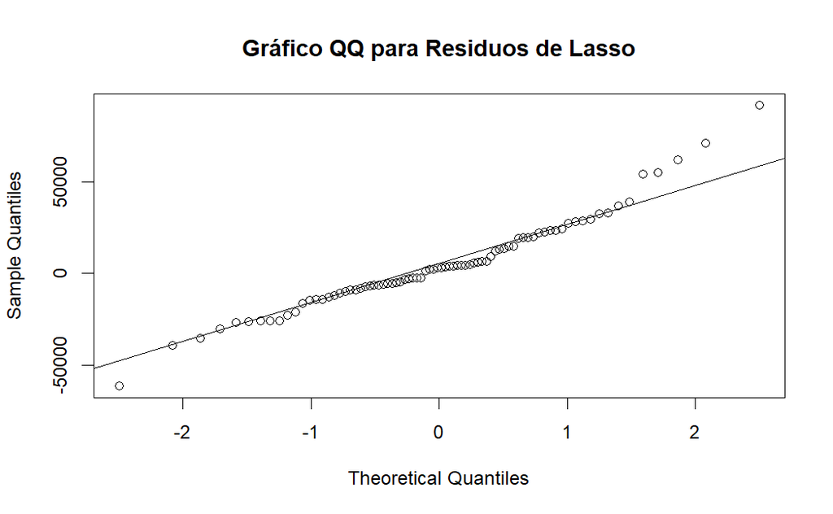

```r
# Gráfico QQ para residuos de Lasso
qqnorm(residuos_lasso, main="Gráfico QQ para Residuos de Lasso")
qqline(residuos_lasso)
```

```r
# Prueba de Shapiro-Wilk
shapiro_test_ridge <- shapiro.test(residuos_ridge)
shapiro_test_lasso <- shapiro.test(residuos_lasso)

# Imprimir los resultados de las pruebas
shapiro_test_ridge
```

```
    Shapiro-Wilk normality test

data:  residuos_ridge
W = 0.95897, p-value = 0.01164
```

```r
shapiro_test_lasso
```

```
    Shapiro-Wilk normality test

data:  residuos_lasso
W = 0.9597, p-value = 0.0129
```

```
Los residuos en un modelo de regresión representan la diferencia entre los valores observados y los valores predichos por el modelo.
```

Sesgo en los Residuos

[output not shown]

Prueba de Shapiro-Wilk

[output not shown]

5. ¿Qué conclusiones extraes de este estudio y del modelo implementado? ¿Consideras correcto el rendimiento del mismo?

Conclusiones del Estudio y del Modelo Implementado

[output not shown]

Rendimiento del Modelo

```
El modelo Ridge mostró un rendimiento aceptable, pero el MSE en el conjunto de prueba fue  alto, lo que indica que el modelo podría mejorar.
```

Sobre el Tema de los Salarios

[output not shown]